# Exercício 1 - TMP - parte computacional

Author

Pedro Henrique Corrêa de Almeida

Seja $X \sim Exp(\lambda)$, e, $X_1, ..., X_n$ uma amostra aleatória de $X$, onde:

$$f(x_1, ..., x_n) = \lambda^n e^{-\lambda \sum_{i=1}^n x_i}$$

Pelo lema de Neyman-Pearson temos que, no caso de hipóteses simples, o teste mais poderoso será o teste de razão de verossimilhanças. Dessa forma, sejam nossas hipóteses:

$$H_0: \lambda = 50 \\
H_1: \lambda = 100$$
Com isso, nosso teste de razão de verossimilhanças é definido como:

$$\delta(X_1, ..., X_n) =
\begin{cases}
Rejeitar\ H_0\ & se\ \frac{L_0}{L_1} \leq k \\
Não\ Rejeitar\ H_0\ & se\ \frac{L_0}{L_1} > k
\end{cases}$$

Podemos calcular $\frac{L_0}{L_1}$ da seguinte forma:

$$\frac{L_0}{L_1} = \frac{\lambda_0^n e^{-\lambda_0 \sum_{i=1}^n X_i}}{\lambda_1^n e^{-\lambda_1 \sum_{i=1}^n X_i}}$$

$$\frac{L_0}{L_1} = \frac{50^n e^{-50 \sum_{i=1}^n X_i}}{100^n e^{-100 \sum_{i=1}^n X_i}}$$

$$\frac{L_0}{L_1} = (\frac{1}{2})^ne^{50 \sum_{i=1}^n X_i}$$

Logo, para rejeitar $H_0$ devemos satisfazer a inequação:

$$\frac{L_0}{L_1} = (\frac{1}{2})^ne^{50 \sum_{i=1}^n X_i} \leq k \\
\sum_{i=1}^n X_i \leq \frac{log(2^n k)}{50}\\
\sum_{i=1}^n X_i \leq k´$$

Para encontrar $k´$ de forma que dependa do erro do tipo I, ou seja, $\alpha$. Vamos utilizar o resultado da soma de $n$ variáveis aleatórias de distribuição exponencial, considerando $H_0$ verdadeira:

$$Y = \sum_{i=1}^n X_i \sim Gama(n, \lambda_0) \\
F_Y(y) = P_{\lambda_0}(Y \leq k´)$$

Como o erro do tipo I é a probabilidade de rejeitar $H_0$ quando esta é verdadeira, podemos definir $k´$ como o quantil que deixa uma área abaixo de $\alpha$ da soma de $n$ váriaveis exponenciais.

$$P_{\lambda_0}(Y \leq k´) = \alpha \\
k´ = F^{-1}(\alpha)$$

# Simulações

Vamos, primeiramente definir o tamanho amostral como $50$ a fim de encontrar qual será o $k´$. Com isso podemos utilizar a função `qgamma` onde a $forma$ será $50$ e a $taxa$ será igual $\lambda_0$, ou seja, $50$:

```r
 # Definindo tamanho
n = 50
 # definindo os valores dos parâmetros
teta_0 = 50
teta_1 = 100

 # Definindo o nível de significância
alpha = 0.05

 # Calculando k´
k_linha = qgamma(alpha, shape = n,
                 rate = teta_0)
k_linha
```

```
[1] 0.7792947
```

Com isso vamos gerar amostras aleatórias de $X\sim Exp(\lambda)$ considerando uma das hipóteses verdadeiras, e, comparar no valor da soma de cada amostra com o valor de $k´$ encontrado, se este valor for menor nós rejeitamos a hipóteses nula e, se este for maior, não rejeitamos a hipótese nula.

## H_0 verdadeira

Primeiro vamos considerar $H_0$ verdadeira e gerar $1000$ amostras de tamanho $50$ de $X\sim Exp(50)$:

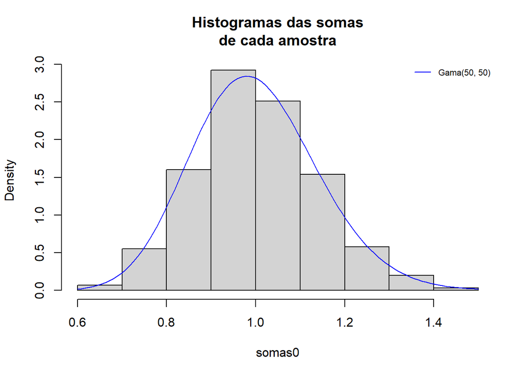

```r
 # Definindo semente
set.seed(123)
 # Gerando as amostras
x0 = replicate(1000, rexp(n, rate = teta_0))
 # Calculando as estatísticas
somas0 = apply(x0, 2, sum)
 # Plotando histograma
hist(somas0, freq = F,
     main = "Histogramas das somas\nde cada amostra")
curve(dgamma(x, shape = n, rate = teta_0),
      col = "Blue", add = T)
legend("topright", col = "blue", lwd = 1,
       legend = "Gama(50, 50)", bty = "n", cex = 0.7)
```

Ao considerar $H_0$ verdadeira vemos como o histograma das somas das amostras se aproxima da curva de densidade de uma $Gama(n, \lambda_0)$ = $Gama(50,50)$.

### Região Crítica

Vamos comparar agora qual a proporção de vezes que a soma ficou abaixo de $k´$, ou seja, que a hipótese nula seria rejeitada com $5\%$ de significância:

```r
mean(somas0 <= k_linha)
```

```
[1] 0.049
```

Temos que $4,9\%$ das vezes a soma foi menor ou igual que $k´$, valor muito próximo do nível de significância como era esperado, uma vez que este se refere a probabilidade de rejeitarmos $H_0$ dado $H_0$ verdadeira.

### Valor-p

Agora vamos compara se fossemos utilizar o método do Valor-p.

```r
p_valores0 = pgamma(somas0, shape = n, rate = teta_0)
summary(p_valores0)
```

```
    Min.  1st Qu.   Median     Mean  3rd Qu.     Max.
0.002114 0.271802 0.508464 0.508622 0.755738 0.997680
```

```r
mean(p_valores0 <= 0.05)
```

```
[1] 0.049
```

Vemos que, pelo valor-p, a proporção de vezes que o valor foi abaixo do nível de significância, ou seja, $H_0$ seria rejeitada, foi $4,9\%$, a mesma comparando a soma com $k´$.

## H1 Verdadeira

Agora vamos gerar uma amostra considerando que $H_1$ seja verdadeira, ou seja, $\lambda=100$ o valor de $k´$ com a soma da amostra de $X \sim Exp(100)$:

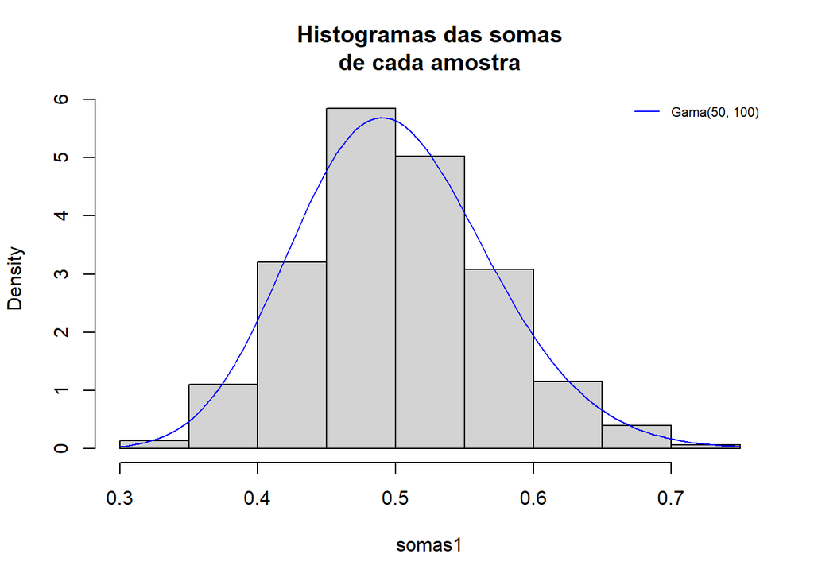

```r
 # Definindo a semente
set.seed(123)
 # Gerando as amostras
x1 = replicate(1000, rexp(n, rate = teta_1))
 # Calculando as estatísticas
somas1 = apply(x1, 2, sum)
 # Plotando o histogramas
hist(somas1, freq = F,
     main = "Histogramas das somas\nde cada amostra")
curve(dgamma(x, shape = n, rate = teta_1),
      col = "Blue", add = T)
legend("topright", col = "blue", lwd = 1,
       legend = "Gama(50, 100)", bty = "n", cex = 0.7)
```

Ao considerar $H_1$ verdadeira vemos como o histograma das somas das amostras se aproxima da curva de densidade de uma $Gama(n, \lambda_1)$ = $Gama(50,100)$.

### Região Crítica

Vamos comparar agora qual a proporção de vezes que a soma ficou abaixo de $k´$, ou seja, que a hipótese nula seria rejeitada com $5\%$ de significância:

```r
mean(somas1 <= k_linha)
```

```
[1] 1
```

Vemos que, gerando as amostras considerando $H_1$ verdadeira, todas as 1000 vezes $H_0$ teria sido rejeitada.

### Valor-p

Agora vamos verificar como seria utilizando o valor-p:

```r
p_valores1 = pgamma(somas1, shape = n, rate = teta_0)
summary(p_valores1)
```

```
     Min.   1st Qu.    Median      Mean   3rd Qu.      Max.
0.000e+00 5.500e-07 6.321e-06 2.383e-04 6.488e-05 1.692e-02
```

Podemos ver que o valor máximo do valor-p foi $< 0,017$, ou seja, todas as vezes, utilizando um nível de significância de $5\%$ teríamos rejeitado a hipótese nula.